# Effect of Economic Factors on Drug Overdose Deaths in Texas

While addiction is class in-discriminant, it is still more common among those with lower economic status(1). Instead of addiction and drug abuse in itself, this report aims to investigate drug overdose-specifically those that result in death. The relationship between key economic variables and potential relation to drug overdose deaths can potentially help narrow down determining factors in drug deaths and combat them. This report looks at counties in texas and the statistics for each variable per county.

From my data I expect to find that all of these economic factors are positively correlated with the amount of deaths per county. Ultimately, this report looks to investigate if key economic factors, median household income, poverty rate, and unemployment rate have an effect on the amount of drug overdose deaths across Texas Counties.

1: “Addiction and Low-Income Americans.” Addiction Center, 26 Oct. 2022, [https://www.addictioncenter.com/addiction/low-income-americans/.](https://www.addictioncenter.com/addiction/low-income-americans/)

2: “Texas Counties: Median Household Income.” Texas Counties: Median Household Income, The County Information Program, Texas Association of Counties, https://txcip.org/tac/census/morecountyinfo.php?MORE=1013.

3:Texas Counties: Percent in Poverty, The County Information Program, Texas Association of Counties, https://txcip.org/tac/census/morecountyinfo.php?MORE=1009.

4:Texas Counties: Unemployment Rate, The County Information Program, Texas Association of Counties, https://txcip.org/tac/census/morecountyinfo.php?MORE=1042.

5:“Texas Counties by Population.” Texas Demographics, https://www.texas-demographics.com/counties_by_population.

```r
#load libraries
library(tidyverse)
library(readr)
library(readxl)
```

A look at all of the data sets used

```r
Texas_overdose <- read_csv("Untitled spreadsheet - Sheet1.csv")
head(Texas_overdose)
```

```
## # A tibble: 6 × 9
##   County   # Drug Overdose Dea…¹ Count…² Error…³ AIAN  Asian Black Hispa…⁴ White
##   <chr>                    <dbl>   <dbl> <chr>   <lgl> <dbl> <dbl>   <dbl> <dbl>
## 1 Texas                     9130      11 10-11   NA       NA    NA      NA    NA
## 2 Anderson                    24      14 9-21    NA       NA    NA      NA    NA
## 3 Andrews                     NA      NA <NA>    NA       NA    NA      NA    NA
## 4 Angelina                    32      12 8-17    NA       NA    NA      NA    NA
## 5 Aransas                     13      18 9-31    NA       NA    NA      NA    NA
## 6 Archer                      NA      NA <NA>    NA       NA    NA      NA    NA
## # … with abbreviated variable names ¹`# Drug Overdose Deaths`, ²`County Value`,
## #   ³`Error Margin`, ⁴Hispanic
```

```r
county_population <- read_csv("county_population - Sheet1.csv")
head(county_population)
```

```
## # A tibble: 6 × 2
##   County         Population
##   <chr>               <dbl>
## 1 Harris County     4697957
## 2 Dallas County     2604722
## 3 Tarrant County    2091953
## 4 Bexar County      1990522
## 5 Travis County     1267795
## 6 Collin County     1039812
```

```r
texas_county_poverty <- read_csv("texas_county_poverty - Sheet1.csv")
head(texas_county_poverty)
```

```
## # A tibble: 6 × 2
##   County    `Percent in Poverty`
##   <chr>     <chr>
## 1 Anderson  20.40%
## 2 Andrews   11.80%
## 3 Angelina  18.40%
## 4 Aransas   15.10%
## 5 Archer    9.60%
## 6 Armstrong 9.90%
```

```r
texas_income <- read_csv("texas_income - Sheet1.csv")
head(texas_income)
```

```
## # A tibble: 6 × 2
##   County    `Median Household Income`
##   <chr>     <chr>
## 1 Anderson  $54,515
## 2 Andrews   $70,005
## 3 Angelina  $50,620
## 4 Aransas   $55,435
## 5 Archer    $69,286
## 6 Armstrong $64,401
```

```r
texas_unemployment <- read_excel("texas_unemploy.xlsx")
head(texas_unemployment)
```

```
## # A tibble: 6 × 6
##   County    `2017` `2018` `2019` `2020` `2021`
##   <chr>      <dbl>  <dbl>  <dbl>  <dbl>  <dbl>
## 1 Anderson   0.037  0.031  0.029  0.057  0.048
## 2 Andrews    0.031  0.024  0.023  0.082  0.059
## 3 Angelina   0.051  0.044  0.04   0.076  0.065
## 4 Aransas    0.069  0.06   0.043  0.084  0.073
## 5 Archer     0.034  0.031  0.028  0.053  0.042
## 6 Armstrong  0.026  0.027  0.027  0.043  0.036
```

### Tidying

Since the texas_unemployment data does not contain a specific variable for year it is not tidy and needs to be fixed. The function pivot_longer was used in order to turn all columns with year values into a single column of all years. The values from the separate columns were turned into the column unemployment_rate.

```r
#tidy data by giving all variables their own column
texas_unemployment <- pivot_longer(texas_unemployment,
                                   cols = c("2017":"2021"),
                                   names_to = "year",
                                   values_to = "unemployment_rate")

texas_unemployment
```

```
## # A tibble: 1,270 × 3
##    County   year  unemployment_rate
##    <chr>    <chr>             <dbl>
##  1 Anderson 2017              0.037
##  2 Anderson 2018              0.031
##  3 Anderson 2019              0.029
##  4 Anderson 2020              0.057
##  5 Anderson 2021              0.048
##  6 Andrews  2017              0.031
##  7 Andrews  2018              0.024
##  8 Andrews  2019              0.023
##  9 Andrews  2020              0.082
## 10 Andrews  2021              0.059
## # … with 1,260 more rows
```

### Joining data sets

All of the data shares the same variable “County” which is what they will be joined on.

```r
#removes "county" from population data
county_population <- county_population%>%
  mutate(County = str_remove_all(County, " County"))
```

```r
nrow(texas_unemployment)
```

```
## [1] 1270
```

```r
nrow(texas_county_poverty)
```

```
## [1] 254
```

```r
nrow(texas_income)
```

```
## [1] 254
```

```r
nrow(Texas_overdose)
```

```
## [1] 255
```

This gives the number of rows in each data set before they are joined, texas_unemployment has 1270 since all years from 2017-2021 are included, texas_county_poverty and texas_income have 254 accounting for each county and Texas_overdose has 255 for each county and texas as a whole.

```r
#joins all datasets together by county
Texas_overdose <- Texas_overdose %>%
  left_join(texas_county_poverty, by = "County" )%>%
  left_join(texas_income, by = "County")%>%
  left_join(texas_unemployment, by = "County")%>%
  left_join(county_population, by = "County")
```

Since we are joining all of the data sets to the overdose data set via county Texas_overdose gains information on poverty rates, unemployment rates, income, and population. This cause the rows to increase to 1271 as we are now including all of the years taken from the unemployment data set.

### Wrangling

Before analysis we need to filter only for data that is relevant to our analysis.

```r
Texas_overdose <- Texas_overdose%>%
  #rename drug overdose deaths to be easier to work with
  rename(Overdose_deaths = "# Drug Overdose Deaths")%>%
  #filter by year and available overdose deaths
  filter(year =="2021", !is.na(Overdose_deaths))%>%
  #only select rows relevant to analysis
  select(County, Overdose_deaths,`Percent in Poverty`,`Median Household Income`,
         year, unemployment_rate, Population)
```

This takes the rows down to 91 as we got rid of all counties that had a null value for overdose deaths and only kept the columns for County, Overdose_deaths,`Percent in Poverty`,`Median Household Income`,year, unemployment_rate, and Population. This could potentially affect analysis as we now have missing data that can not be considered.

We will now further clean up the data to allow easier analysis.

```r
Texas_overdose <- Texas_overdose%>%
  #removes characters turns value to numeric and decimal point
  mutate(`Percent in Poverty` =
           as.numeric(sub("%", "",Texas_overdose$`Percent in Poverty`))/100)%>%
 #turns value into numeric removing characters
   mutate(`Median Household Income (USD)` =
           as.numeric(gsub("[$,]", "",Texas_overdose$`Median Household Income`)))%>%
  #creates a categorical variable out of household income
  mutate(Income_Brackets =
            case_when(`Median Household Income (USD)` >= 40000  &
                        `Median Household Income (USD)` <= 60000 ~ '40-60k',
                      `Median Household Income (USD)` >= 60001  &
                        `Median Household Income (USD)` <= 80000 ~ '60-80k',
                      `Median Household Income (USD)` >= 80001  &
                        `Median Household Income (USD)`<= 100000 ~ '80-100k',
                      `Median Household Income (USD)` >= 100001  ~ '100k+'))%>%
  #normalizes death data with population
  mutate(death_per_100k =
           Overdose_deaths/(Population/100000))
```

This mutates percent in poverty and median household income to numeric variable to be easier to analyze. We also creates a categorical variable, Income_brackets, that splits the income into four categories for a more general overview of the variable. Now we can compute summary statistics for the economic factors and explore potential relationships.

```r
Texas_overdose %>%
  #group by income
  group_by(Income_Brackets)%>%
  #mean deaths per bracket
  summarize(avg_deaths = mean(death_per_100k))
```

```
## # A tibble: 4 × 2
##   Income_Brackets avg_deaths
##   <chr>                <dbl>
## 1 100k+                 25.3
## 2 40-60k                37.5
## 3 60-80k                35.4
## 4 80-100k               27.4
```

Looking at the average deaths for each income bracket we can see that there is a very slight decrease in the average amount of deaths as the income bracket increases.

```r
Texas_overdose %>%
  #quantiles for deaths, unemployment, and poverty
  summarize(death_quantile =quantile(death_per_100k, c(0,0.5,1)),
            quantile(unemployment_rate,c(0,0.5,1)),
            quantile(`Percent in Poverty`,c(0,0.5,1)))
```

```
## # A tibble: 3 × 3
##   death_quantile `quantile(unemployment_rate, c(0, 0.5, 1))` quantile(\Percent…¹
##            <dbl>                                       <dbl>               <dbl>
## 1           11.4                                       0.035               0.051
## 2           32.4                                       0.055               0.146
## 3           79.9                                       0.102               0.288
## # … with abbreviated variable name
## #   ¹`quantile(\`Percent in Poverty\`, c(0, 0.5, 1))`
```

```r
Texas_overdose%>%
  #keep relevant columns
  select(County,unemployment_rate,death_per_100k)%>%
  #find top 5 unemployment rates
  arrange(desc(unemployment_rate))%>%
  head(5)
```

```
## # A tibble: 5 × 3
##   County    unemployment_rate death_per_100k
##   <chr>                 <dbl>          <dbl>
## 1 Jim Wells             0.102           28.1
## 2 Jefferson             0.1             37.4
## 3 Jasper                0.097           53.9
## 4 Hidalgo               0.093           11.4
## 5 Liberty               0.092           36.7
```

```r
Texas_overdose%>%
  #keep relevant columns
  select(County,`Percent in Poverty`,death_per_100k)%>%
  #find top 5 poverty rates
  arrange(desc(`Percent in Poverty`))%>%
  head(5)
```

```
## # A tibble: 5 × 3
##   County    `Percent in Poverty` death_per_100k
##   <chr>                    <dbl>          <dbl>
## 1 Hidalgo                  0.288           11.4
## 2 Cameron                  0.246           14.5
## 3 Walker                   0.239           22.2
## 4 Jasper                   0.238           53.9
## 5 Matagorda                0.229           30.3
```

We can see here that our above assumption is not true for unemployment rate or poverty percentage as we see deaths under 32 even at the top 5 values for these variables. In order to examine the true relationship we will need to create visualizations.

### Visualizations

In order to best see how the economic factors effect the death rates it is best to create visualizations.

First let’s look at the distribution of the death_per_100k column.

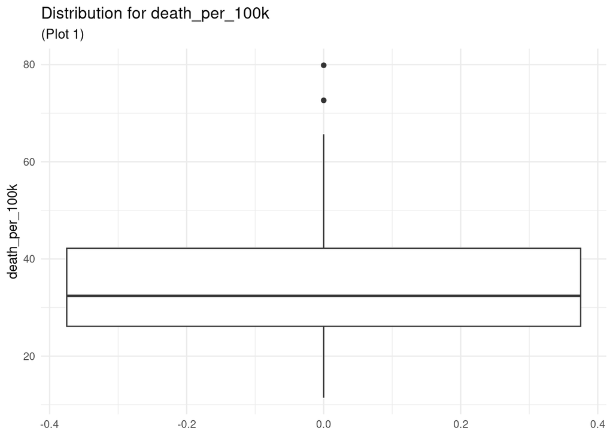

```r
ggplot(data = Texas_overdose, aes(y=death_per_100k))+
  geom_boxplot()+
  scale_y_continuous(breaks = seq(0, 80, 20))+
  labs(title = "Distribution for death_per_100k",
       subtitle = '(Plot 1)')+
  theme_minimal()
```

This plot shows the quartiles for the death_per_100k data. It is useful to visualize this data to determine how it should be used in relation to our other variables. Here we can see that the data has a pretty even spread despite two outliers. However, since these outliers are still within the range of the question we are asking they will still be included in further analysis.

We can view the relation between our categorical variable, income_brackets, and overdose deaths with a bar plot.

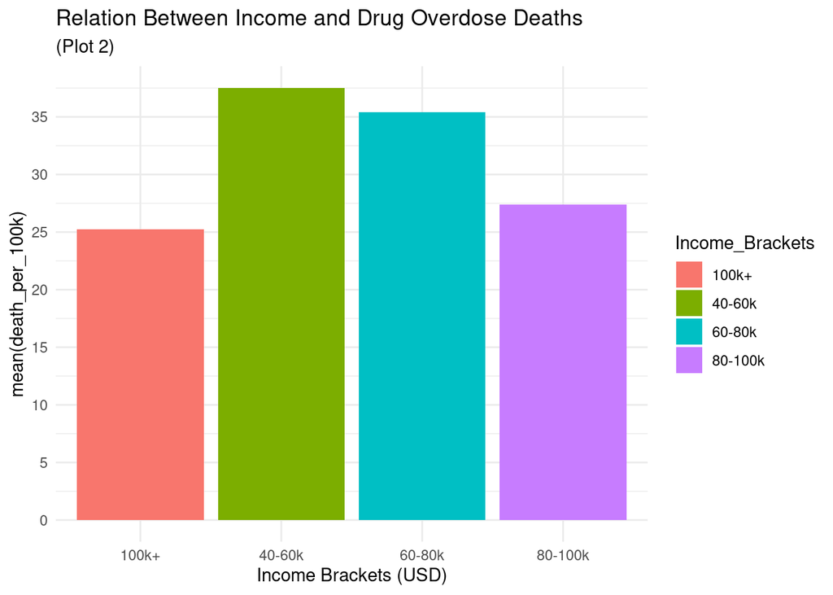

```r
ggplot(data = Texas_overdose, aes(x= Income_Brackets, y = death_per_100k,
                                  fill = Income_Brackets))+
  geom_bar(stat = "summary",fun = "mean")+
  scale_y_continuous(breaks = seq(0, 40, 5))+
  labs(title = "Relation Between Income and Drug Overdose Deaths",
       subtitle = "(Plot 2)",
       y = "mean(death_per_100k)",
       x= "Income Brackets (USD)")+
  theme_minimal()
```

This bar plot shows the realtion between different income brackets and the average deaths within each bracket. Income is a large overarching economic factor and so it is useful to visualize it on its own to determine its effect, if any, on drug overdose deaths. From this we can see a slight negative relationship in which as income increases the average deaths by drug overdose will also decrease.

We can visualize our other two economic factors with bubble plots.

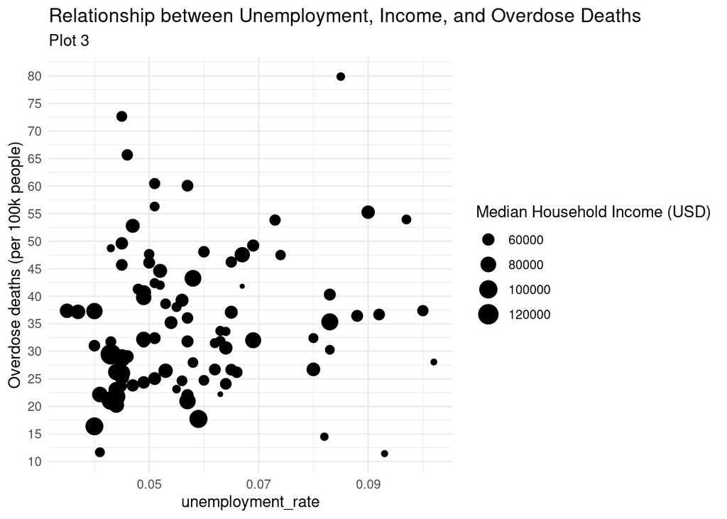

```r
ggplot(data = Texas_overdose, aes(x = unemployment_rate, y = death_per_100k,
                                  size = `Median Household Income (USD)`)) +
  geom_point() +
  scale_y_continuous(breaks = seq(0, 80, 5))+
  theme_minimal()+
  labs(title = "Relationship between Unemployment, Income, and Overdose Deaths",
       y = "Overdose deaths (per 100k people)",
       subtitle = "Plot 3")
```

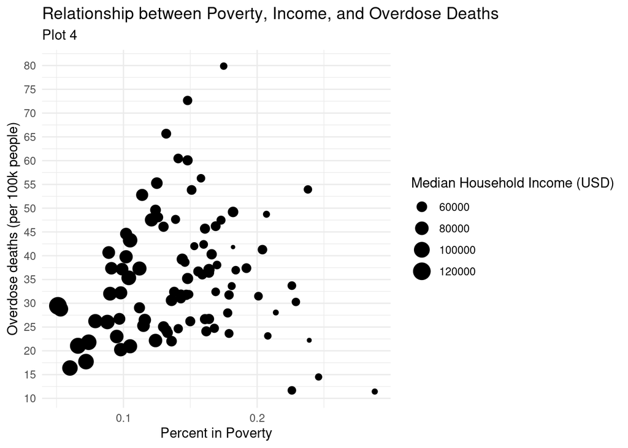

```r
ggplot(data = Texas_overdose, aes(x = `Percent in Poverty`, y = death_per_100k,
                                  size = `Median Household Income (USD)`)) +
  geom_point() +
  scale_y_continuous(breaks = seq(0, 80, 5))+
  theme_minimal()+
  labs(title = "Relationship between Poverty, Income, and Overdose Deaths",
       y = "Overdose deaths (per 100k people)",
       subtitle = "Plot 4")
```

These first plot for unemployment rate includes the rate, deaths, and median income. It is useful to also include the numerical income in this graph to get a better grasp on its effect compared to the categorical approach. From this graph we can see that there doesnt appear to be any strong correlation between unemployment rate and deaths with the income being slightly correlated.

The second plot is in identical style showing the poverty rate, deaths, and income. Here the relationships appears stronger yet there are still irregularities. As poverty percentage increases the deaths also tend to increase to some degree. The decreasing size relating to income makes sense as poverty rate and median income are closely related.

### Discussion

This report aimed to determine if key economic factors (Median household income, Poverty percentage, unemployment rate) affected the number of deaths by drug overdose across Texas counties. The most vital determinants in answering this question were the visualizations created. From plot 2 we can see that there does seem to be a relationship between the median household income and the deaths that occurred. This relationship is relatively small and is therefore not likely to be a vital answer to the question. Similarly, unemployment rate and poverty percentage do not seem to be strong determining factors for deaths either. This is shown in plots 3 and 4 where the relationships are generally scattered.The fact that none of our economic factors were strongly correlated leads us to believe that there are other factors that play a larger role in this problem. These likely include problems such as mental health and familial support that are not easily quantifiable.

Overall, this project has been helpful in pulling together all of the analysis and coding skills we have used thus far in the class. The most challenging part of the project was figuring out how to create a cohesive narrative for the analysis that clearly shows the actions taken to answer the research question. This project has made me interested in working with bigger data sets and more challenging questions to use new skills.